# Redfish notes

07-14-2020

Sebastes_marinus. Official name is Sebastes norvegicus (golden redfish), changed in 2015

Fishbase: Depth range 100-1000m, usually 100-500. Temp: 0.6-9.3 38cm at maturity, common 45, max 100, max 15kg

Juveniles inshore, usually found in deep water

Diet: euphausiids in summer, herring in autumn and winter, capelin/herring, euphausiids, ctenophores in spring

```r
# sample ID of all red presences and absences
red_pa <- read_csv ("../Data/PA_MFRI.csv",
                     col_types = cols(
                       sample_id = col_factor()
                     )) %>%
  select (sample_id, Sebastes_marinus)
# full MFRI info for all red presences, retaining length data
red_samp_full <- read_csv ("../Data/MFRI_comb_survey.csv",
                      col_types = cols(
                      sample_id = col_factor(),
                      species = col_factor(),
                      stat_sq = col_factor()
                      )
                      )%>%
  filter (species == 5, !(year == 2011 & season == "autumn")) # remove autumn 2011
# all red presences, grouped by sample_ID (lengths aggregated
red_samp <- red_samp_full %>%
  group_by (sample_id) %>%
  summarize (n_tot = sum(n_per_nautmile, na.rm = TRUE),
             kg_tot = sum(kg_per_nautmile, na.rm = TRUE),
             station = first(station),
             lat = first(lat),
             lon = first(lon),
             year = first(year),
             date = first(date),
             season = first(season)
  ) %>%
  mutate (n_log = log (n_tot),
          kg_log = log(kg_tot))
```

Present in 24065 samples (82.9770361%). This might be the most so far! Almost as much as cod (25185) ### Histograms

[figure not shown]

Just an overall wider distribution in the spring, more very small individuals and very large.

## biomass and abundance dotcharts

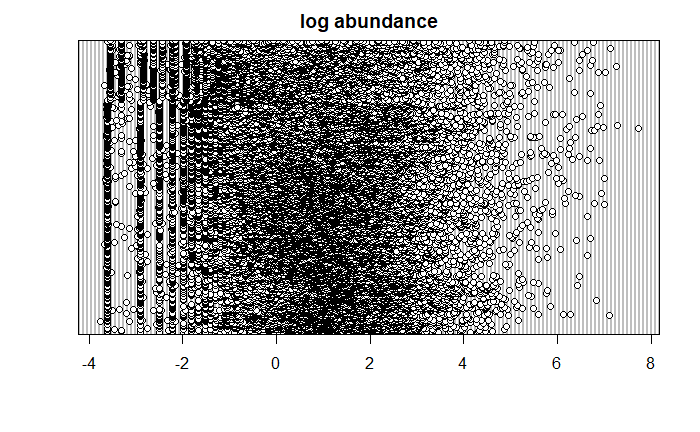

One potential large abundance value, above 2000. maybe shows up on log abundance but hardly. Sample id 439319, march 2016.

```r
red_samp %>%
  filter (n_tot > 2000)

red_samp$n_tot[which (red_samp$n_tot > 2000)] > quantile (red_samp$n_tot, 0.75) + 1.5 * (quantile (red_samp$n_tot, 0.75) - quantile (red_samp$n_tot, 0.25)) # yes
```

[output not shown]

### Trends in abundance and biomass over time

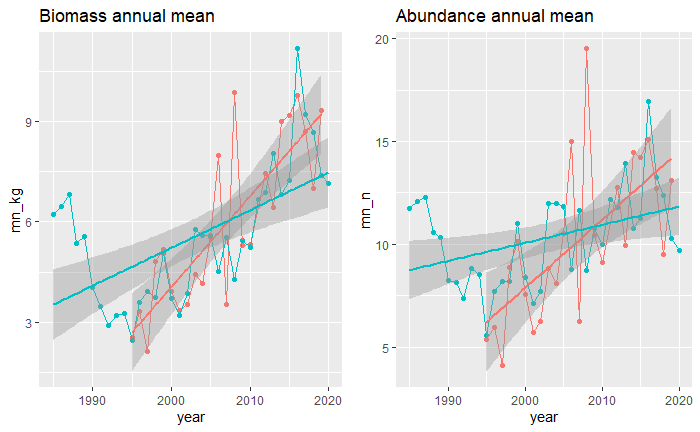

Generally rising in both seasons, faster in fall but very similar trend if we just look after 2000. looks like declined until 1995 and then has increased.

### Spatial distribution

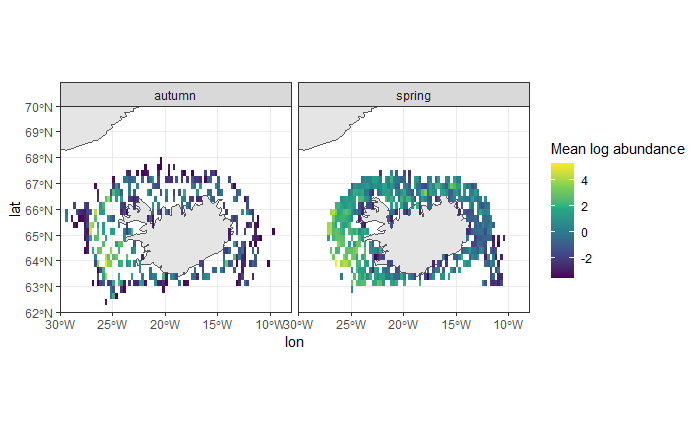

More offshore, more evenly distributed. West, and further offshore.

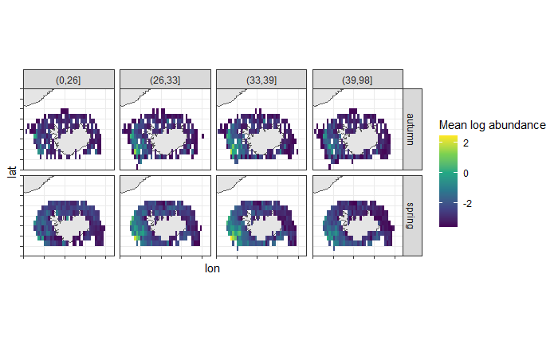

Not sure there’s a separate pattern, just more concentration of medium sized ones offshore west in spring and fall.

### Plot abundance vs. predictor variables

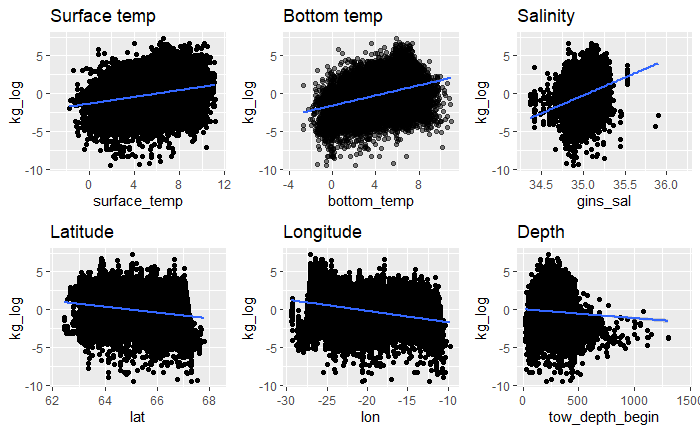

Pos with temp, sal. negative with latitude, longitude, depth. surprising because this should be the deepest so far, but looks like not too abundant in the outermost fall surveys. can’t tell from fishbase description if there’s seasonal migration that would explain this. ### Model results

```r
summary (gam_PA)
```

```
Family: binomial
Link function: logit

Formula:
Presence ~ te(lon, lat) + year + season + s(surface_temp) + s(bottom_temp) +
    s(gins_sal) + s(tow_depth_begin)

Parametric coefficients:
              Estimate Std. Error z value Pr(>|z|)
(Intercept)  26.927558  11.409048    2.36   0.0183 *
year         -0.012254   0.005699   -2.15   0.0315 *
seasonspring  1.593015   0.113663   14.02   <2e-16 ***
---
Signif. codes:  0 ‘***’ 0.001 ‘**’ 0.01 ‘*’ 0.05 ‘.’ 0.1 ‘ ’ 1

Approximate significance of smooth terms:
                      edf Ref.df   Chi.sq  p-value
te(lon,lat)        23.139 23.782  711.504  < 2e-16 ***
s(surface_temp)     1.000  1.001    3.719 0.053847 .
s(bottom_temp)      1.604  2.016   45.750 1.25e-10 ***
s(gins_sal)         6.376  7.488   29.583 0.000416 ***
s(tow_depth_begin)  7.588  8.276 1208.846  < 2e-16 ***
---
Signif. codes:  0 ‘***’ 0.001 ‘**’ 0.01 ‘*’ 0.05 ‘.’ 0.1 ‘ ’ 1

R-sq.(adj) =  0.669   Deviance explained = 65.1%
UBRE = -0.708  Scale est. = 1         n = 19081
```

SST not significant, year barely

Partial plots

```r
par (mfrow = c (2, 3), mar = c (2, 1.5, 1.5, 1.5), oma = c(0,1,2,0))
plot (gam_PA, residuals = TRUE,
      select = 1,
      ylab = "", xlab = "",
      main = paste ("te(Lon, Lat)", round (summary (gam_PA)$edf[1], 2), sep = ", "))
plot (gam_PA, residuals = TRUE,
      select = 2,
      ylim = c (-5, 5),
      ylab = "", xlab = "",
      main = paste ("s(sst)", round (summary (gam_PA)$edf[2], 2), sep = ", "))
```

```r
plot (gam_PA, residuals = TRUE,
      select = 3,
      ylim = c (-10, 10),
      ylab = "", xlab = "",
      main = paste ("s(bt)", round (summary (gam_PA)$edf[3], 2), sep = ", "))
plot (gam_PA, residuals = TRUE,
      select = 4,
      ylim = c (-5, 5),
      ylab = "", xlab = "",
      main = paste ("s(sal)", round (summary (gam_PA)$edf[4], 2), sep = ", "))
```

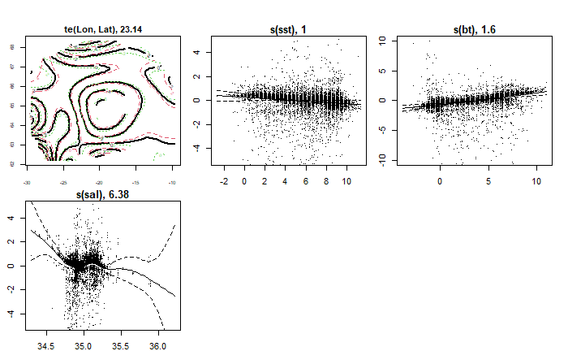

```r
plot (gam_PA, residuals = TRUE,
      select = 5,
      ylim = c (-10, 25),
      ylab = "", xlab = "",
      main = paste ("s(depth)", round (summary (gam_PA)$edf[5], 2), sep = ", "))
```

[output not shown]

```r
NA
NA
```

```r
save (single.var.comp, file = "../Models/PresAbs_summary_tables/red_single_var_comp.RData")
```

```r
summary (gam_LB)
```

```
Family: gaussian
Link function: identity

Formula:
kg_log ~ te(lon, lat) + year + season + s(surface_temp) + s(bottom_temp) +
    s(gins_sal) + s(tow_depth_begin)

Parametric coefficients:
              Estimate Std. Error t value Pr(>|t|)
(Intercept)   5.587670   3.217408   1.737   0.0825 .
year         -0.003365   0.001609  -2.092   0.0365 *
seasonspring  1.037933   0.042832  24.233   <2e-16 ***
---
Signif. codes:  0 ‘***’ 0.001 ‘**’ 0.01 ‘*’ 0.05 ‘.’ 0.1 ‘ ’ 1

Approximate significance of smooth terms:
                      edf Ref.df       F  p-value
te(lon,lat)        23.794 23.981 178.515  < 2e-16 ***
s(surface_temp)     7.279  8.193   8.154 2.95e-11 ***
s(bottom_temp)      8.139  8.752  49.938  < 2e-16 ***
s(gins_sal)         7.873  8.697   5.547 5.57e-07 ***
s(tow_depth_begin)  8.605  8.940 166.992  < 2e-16 ***
---
Signif. codes:  0 ‘***’ 0.001 ‘**’ 0.01 ‘*’ 0.05 ‘.’ 0.1 ‘ ’ 1

R-sq.(adj) =  0.479   Deviance explained = 48.1%
GCV = 2.0246  Scale est. = 2.0173    n = 16334
```

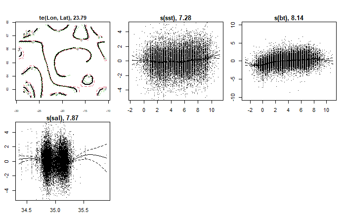

slight positive with bottom temp. might need to look without residuals to see salinity and depth patterns better.

| Var | R2_full | R2_s | R2_d | Diff_full |
| --- | --- | --- | --- | --- |
| te (lon, lat) | 48.08 | 33.96 | 34.51 | -13.57 |
| year | 48.08 | 0.35 | 48.07 | -0.01 |
| season | 48.08 | 1.37 | 46.24 | -1.84 |
| s(surface_temp) | 48.08 | 9.44 | 47.67 | -0.41 |
| s(bottom_temp) | 48.08 | 19.20 | 46.95 | -1.12 |
| s(gins_sal) | 48.08 | 16.31 | 47.46 | -0.62 |
| s(tow_depth_begin) | 48.08 | 7.40 | 43.31 | -4.77 |

Everything contributes here, year lest of all. lat/lon and depth most difference for dropping, but temp and salinity have pretty big r2 single.